# In-Class Likelihoods

David Murillo

October 25, 2022

# Questions

Consider the likelihood calculation example for 2 observations of Wilson’s Warblers using a Poisson distribution model.

- Recall the R-code I used in the walkthrough to find the log-likelihood of using λ=4.5:

As a group, experiment with different values of λ to find a value that maximizes the sum of log-likelihoods of the hypothetical observations.

wiwa_counts = c(2, 6) dpois(x = wiwa_counts, lambda = 5)

sum(log(dpois(x = wiwa_counts, lambda = 4)))

## **Q1 (1 pt.): What value for λ did you select?**

*Answer: 4*

## **Q2 (1 pt.): How did you choose a value?**

*Answwer: Because is the mean of 2 and 6*

In the walkthrough, I tried using a Poisson distribution with λ=1.0 to model the set of census counts of Wilson’s Warbler.

You will create models for the census count of Winter Wrens.

- Find the λ value of a Poisson model that makes all of the observed the Winter Wren’s census counts most likely.

```r
mean(dat_bird$WIWR)
```

```
[1] 1.456023
```

- Plot a histogram of Winter Wren counts (Check the metadata file to find the abbreviation for Winter Wrens). Make sure you choose an appropriate number of bins for the plot.

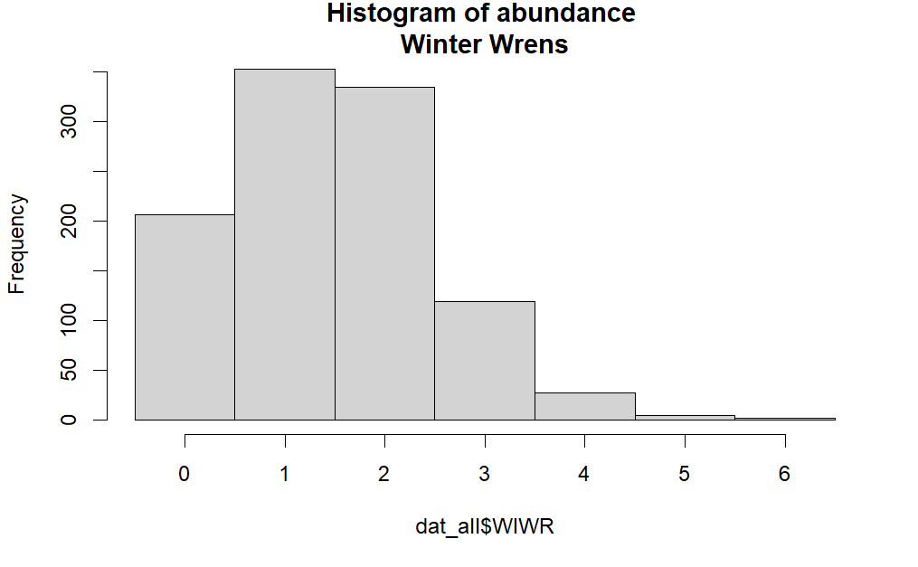

```r
hist(dat_all$WIWR, breaks = 0:7 - .5, main = "Histogram of abundance \n Winter Wrens ")
```

- As a group, you’ll be searching for the value of λ that maximizes the sum of log-likelihood. In other words, you’ll find the the model parameter that makes the values of observed wren census counts most likely.

```r
sum(log(dpois(x = dat_all$WIWA, lambda = 1.45)))
```

```
[1] -1561.435
```

- Hint: you only need to consider 2 significant figures in your value of λ.

## **Q3 (1 pt.): Include your histogram into your report.**

```r
png(filename = "WIWR_Histogram.png", width = 6, height = 4, res = 300, units = "cm")

hist(dat_all$WIWR, breaks = 0:7 - .5,
     main = "Histogram of abundance \n Winter Wrens",
     xlab = "Abundance")
```

[output not shown]

**Q4 (1 pt.): What value for λ did you select?**

*Answer: 1.45*

**Q5 (2 pts.): Show the R code you used to calculate the Poisson log-likelihood for the vector of Winter Wren census counts.**

In the walkthrough, I tried using a Poisson distribution with λ=1.0 to model the set of census counts of Wilson’s Warblers.

You will create models for the census count of Winter Wrens.

Suppose you wanted to use a binomial distribution instead of a Poisson distribution.

Find values of the parameters for a binomial distribution that make the vector of census counts most likely.

```r
sum(log(dbinom(x = dat_all$WIWA, size = 6, prob = 0.024)))
```

**Q6 (1 pt.): What are the two parameters for a binomial distribution and what do they represent?**

*Answer: The sample size and the probability*

**Q7 (2 pts.): What were the parameter values you selected?**

**Q8 (1 pt.): How did you choose a value for n?**

**Q9 (2 pts.): Show R code you used to calculate the binomial log-likelihood for the vector of Winter Wren census counts.**

*Answer:*

```r
sum(log(dbinom(x = dat_all$WIWA, size = max(dat_bird$WIWR), prob = 0.24)))
```

```
[1] -1532.541
```